# Pemodelan ARIMA Suhu Rata-Rata Harian Malaysia

Muhammad Khayruhanif

30 September 2026

# Persiapan

Analisis ini memodelkan **suhu rata-rata harian Malaysia** menggunakan ARIMA dengan **500 observasi awal**.

```r
library(ggplot2)
library(tsibble)
library(tseries)
library(MASS)
library(forecast)
library(lmtest)
library(readxl)
```

## Impor Data

```r
dat <- read_excel("C:\\Users\\ASUS\\Downloads\\Data Suhu Rata-Rata Harian Malaysia.xlsx")
names(dat) <- c("DATE", "Suhu")
dat$DATE <- as.Date(as.character(dat$DATE), format = "%Y%m%d")

dat500 <- dat[1:500, ]

head(dat500)
```

```
## # A tibble: 6 × 2
##   DATE        Suhu
##   <date>     <dbl>
## 1 1968-01-01  25.1
## 2 1968-01-02  24.9
## 3 1968-01-03  24.5
## 4 1968-01-04  24.7
## 5 1968-01-05  25.1
## 6 1968-01-06  24.7
```

```r
tail(dat500)
```

```
## # A tibble: 6 × 2
##   DATE        Suhu
##   <date>     <dbl>
## 1 1969-05-09  28.3
## 2 1969-05-10  28.8
## 3 1969-05-11  28.2
## 4 1969-05-12  28.2
## 5 1969-05-13  29.1
## 6 1969-05-14  28.4
```

Pada file, nilai `-999.9` dipakai sebagai kode data hilang. Berikut pengecekan pada 500 data awal:

```r
c(NA_asli = sum(is.na(dat500$Suhu)),
  kode_hilang = sum(dat500$Suhu <= -999),
  tanggal_awal = format(min(dat500$DATE)),
  tanggal_akhir = format(max(dat500$DATE)))
```

```
##       NA_asli   kode_hilang  tanggal_awal tanggal_akhir
##           "0"           "0"  "1968-01-01"  "1969-05-14"
```

Pada 500 data awal tidak terdapat data hilang, sehingga data dapat langsung digunakan.

```r
summary(dat500$Suhu)
```

```
##    Min. 1st Qu.  Median    Mean 3rd Qu.    Max.
##   23.20   26.00   27.00   26.77   27.60   29.10
```

## Plot Deret Waktu 500 Data Awal

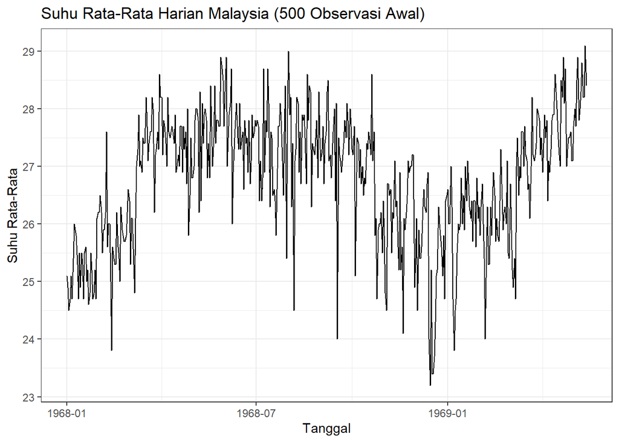

```r
ggplot(dat500, aes(x = DATE, y = Suhu)) +
  geom_line() + theme_bw() +
  xlab("Tanggal") + ylab("Suhu Rata-Rata") +
  ggtitle("Suhu Rata-Rata Harian Malaysia (500 Observasi Awal)")
```

# Partisi Data Deret Waktu

Data dibagi menjadi **data latih (observasi 1 - 400)** dan **data uji (observasi 401 - 500)** dengan proporsi 80:20.

```r
n_train <- 400

y     <- dat500$Suhu |> ts()
train <- y[1:n_train] |> ts()
test  <- y[(n_train + 1):500]

length(train); length(test)
```

```
## [1] 400
```

```
## [1] 100
```

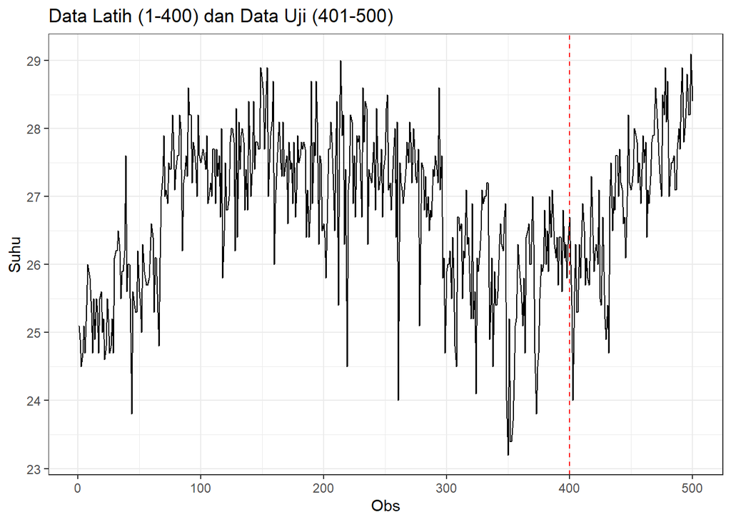

```r
plot_all <- y |> as_tsibble() |>
  ggplot(aes(x = index, y = value)) +
  geom_line() + theme_bw() +
  xlab("Obs") + ylab("Suhu") +
  geom_vline(xintercept = n_train, linetype = "dashed", color = "red") +
  ggtitle("Data Latih (1-400) dan Data Uji (401-500)")
plot_all
```

# Eksplorasi Kestasioneran Data Latih

## Plot Time Series

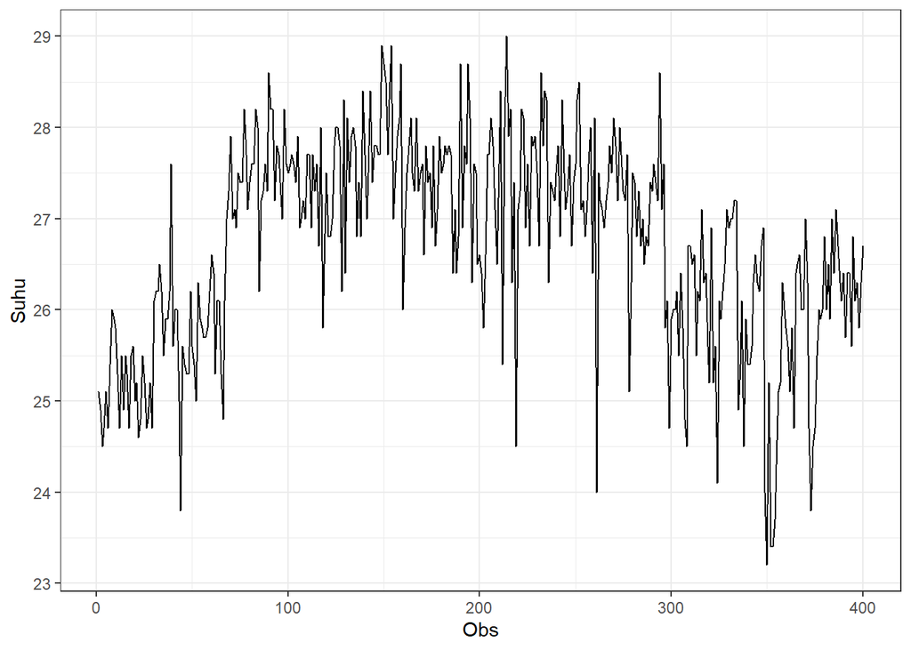

```r
plot_train <- train |> as_tsibble() |>
  ggplot(aes(x = index, y = value)) +
  geom_line() + theme_bw() +
  xlab("Obs") + ylab("Suhu")
plot_train
```

```r
mean(train)
```

```
## [1] 26.6965
```

```r
var(train)
```

```
## [1] 1.279386
```

```r
seg <- split(as.numeric(train), rep(1:4, each = 100))
tab_seg <- data.frame(
  Bagian = c("Obs 1-100", "Obs 101-200", "Obs 201-300", "Obs 301-400"),
  Rataan = sapply(seg, mean),
  Ragam  = sapply(seg, var)
)
knitr::kable(tab_seg, digits = 3, row.names = FALSE)
```

| Bagian | Rataan | Ragam |
| --- | --- | --- |
| Obs 1-100 | 26.177 | 1.249 |
| Obs 101-200 | 27.490 | 0.418 |
| Obs 201-300 | 27.247 | 0.752 |
| Obs 301-400 | 25.872 | 0.836 |

Berdasarkan plot deret waktu, data berfluktuasi naik turun dengan rataan yang bergeser antar periode (tabel di atas), sehingga data diduga **belum stasioner dalam rataan**. Lebar fluktuasi juga tidak sepenuhnya sama tiap bagian, sehingga kestasioneran dalam ragam perlu dicek dengan plot Box-Cox.

## Plot ACF dan PACF

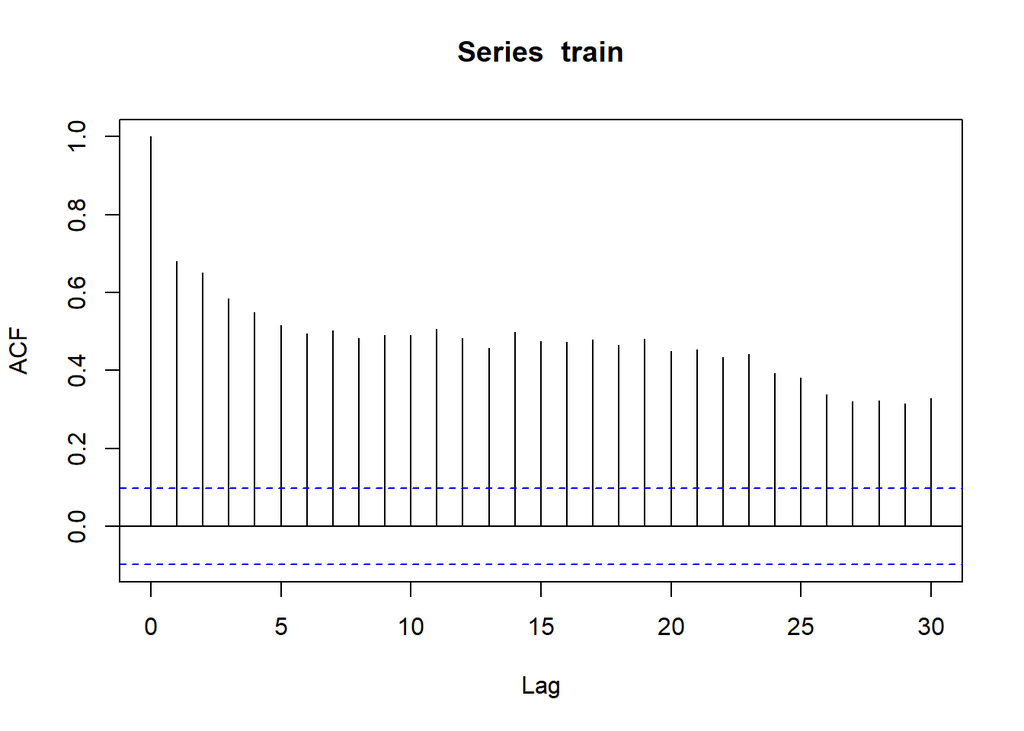

```r
acf(train, lag.max = 30)
```

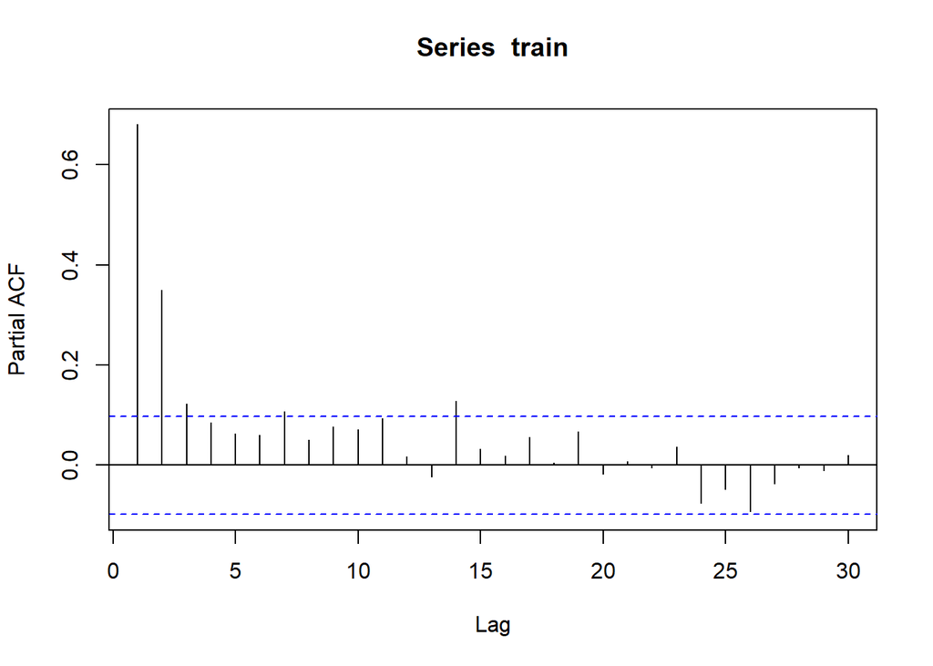

```r
pacf(train, lag.max = 30)
```

Berdasarkan plot ACF, terlihat bahwa nilai autokorelasi **menurun secara perlahan (tails off slowly)** dan tetap berada di luar batas signifikansi pada banyak lag. Hal ini menandakan data tidak stasioner dalam rataan.

## Uji ADF

Uji ADF (Augmented Dickey-Fuller) digunakan untuk memeriksa kestasioneran dalam rataan.

```r
adf_level <- tseries::adf.test(train)
adf_level
```

```
##
##  Augmented Dickey-Fuller Test
##
## data:  train
## Dickey-Fuller = -3.1039, Lag order = 7, p-value = 0.111
## alternative hypothesis: stationary
```

$H_0$ : Data tidak stasioner dalam rataan

$H_1$ : Data stasioner dalam rataan

## Plot Box-Cox

```r
index <- seq(1, length(train))

# Box-Cox
bc <- boxcox(
  train ~ index,
  lambda = seq(-2, 10, by = 0.01)
)
```

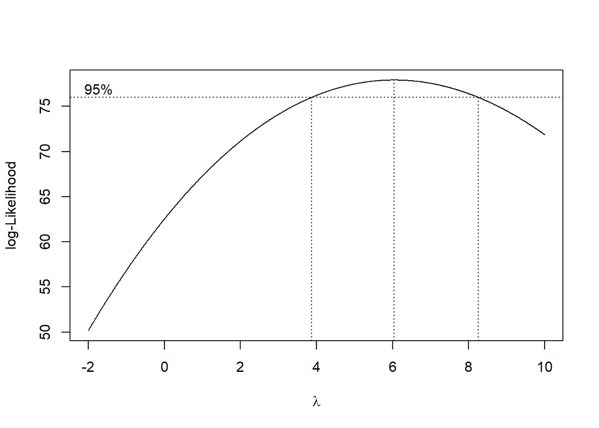

```r
# Nilai lambda optimum
lambda_opt <- bc$x[which.max(bc$y)]
lambda_opt
```

```
## [1] 6.04
```

```r
# Selang kepercayaan 95% untuk lambda
ci_lambda <- bc$x[bc$y > max(bc$y) - 0.5 * qchisq(0.95, 1)]
ci_lower <- min(ci_lambda)
ci_upper <- max(ci_lambda)
c(Batas_Bawah = ci_lower, Batas_Atas = ci_upper)
```

```
## Batas_Bawah  Batas_Atas
##        3.87        8.25
```

## Differencing

Karena data latih belum stasioner dalam rataan, dilakukan differencing pertama:

$$\nabla Y_t = Y_t - Y_{t-1}$$

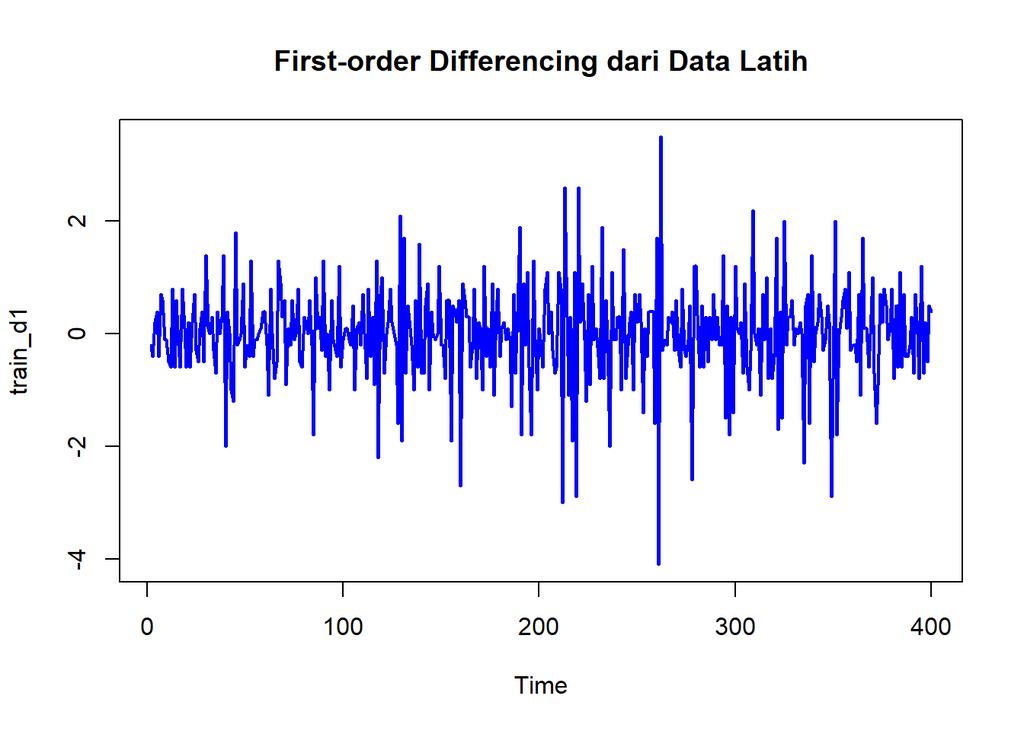

```r
train_d1 <- diff(train, differences = 1)

ts.plot(train_d1,
        main = "First-order Differencing dari Data Latih",
        col = "blue", lwd = 2)
```

### Plot ACF dan PACF

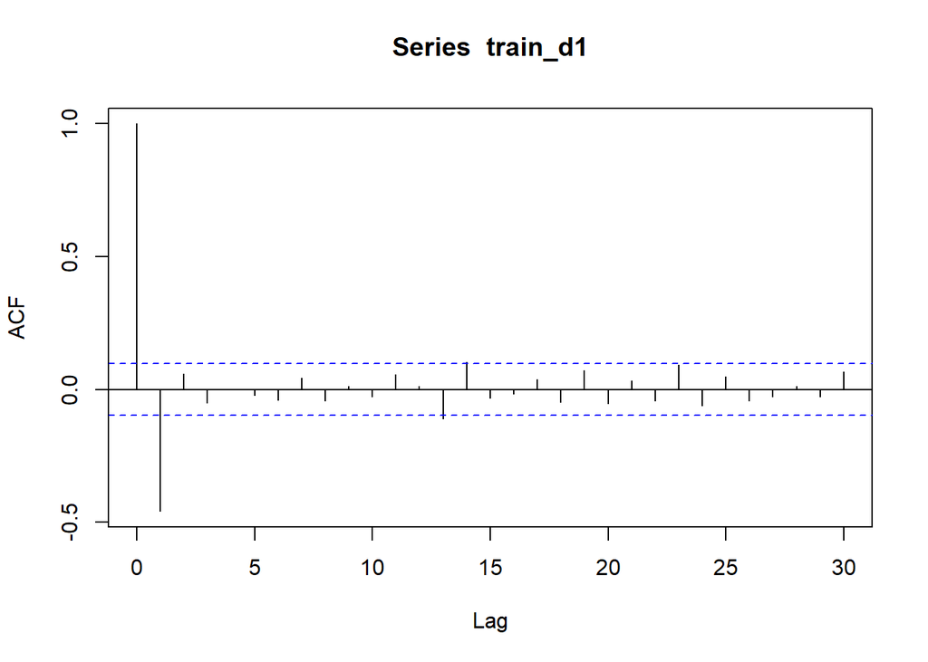

```r
acf(train_d1, lag.max = 30)
```

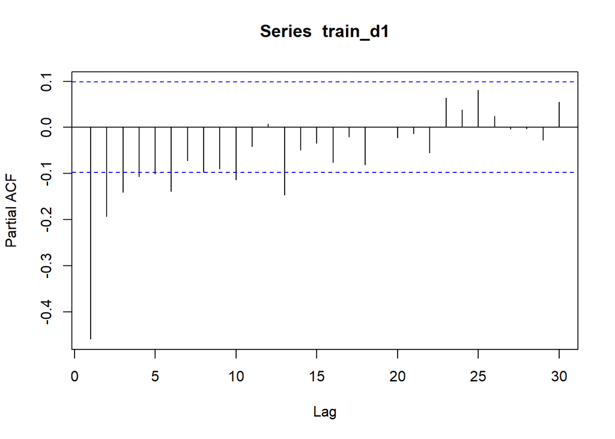

```r
pacf(train_d1, lag.max = 30)
```

Berdasarkan plot ACF, terlihat bahwa data hasil differencing berfluktuasi di sekitar nol dan ACF **cuts off setelah lag 1** (lag 1 bernilai negatif dan signifikan, lag berikutnya berada di dalam batas). Sementara itu, plot PACF cenderung **tails off**. Pola ini mengarah pada komponen MA(1) setelah differencing pertama.

### Uji ADF

```r
adf_d1 <- tseries::adf.test(train_d1)
adf_d1
```

```
##
##  Augmented Dickey-Fuller Test
##
## data:  train_d1
## Dickey-Fuller = -10.673, Lag order = 7, p-value = 0.01
## alternative hypothesis: stationary
```

# Identifikasi Model

Berdasarkan plot ACF (cuts off setelah lag 1) dan PACF (tails off) pada bagian sebelumnya, model dugaan utama adalah **ARIMA(0,1,1)**.

## EACF

```r
# Membutuhkan paket TSA (install.packages("TSA") bila belum ada)
if (requireNamespace("TSA", quietly = TRUE)) {
  TSA::eacf(train_d1, ar.max = 5, ma.max = 5)
} else {
  message("Paket TSA belum terpasang, bagian EACF dilewati.")
}
```

```
## AR/MA
##   0 1 2 3 4 5
## 0 x o o o o o
## 1 x x o o o o
## 2 x o o o o o
## 3 x o o o o o
## 4 x x o o x o
## 5 x x x x o o
```

Dari seluruh hasil identifikasi, model dugaan yang dibandingkan adalah:

1. ARIMA(0,1,1)
2. ARIMA(1,1,1)
3. ARIMA(0,1,2)
4. ARIMA(1,1,0)
5. ARIMA(1,1,2)

# Pendugaan Parameter dan Pemilihan Model

Model terbaik dipilih berdasarkan kriteria berikut:

- seluruh parameter signifikan pada taraf nyata 5%, dan
- nilai AIC paling kecil di antara model yang seluruh parameternya signifikan.

```r
orders <- list(c(0,1,1), c(1,1,1), c(0,1,2), c(1,1,0), c(1,1,2))
fits   <- lapply(orders, function(o) Arima(train, order = o))

tabel <- data.frame(
  Model      = sapply(orders, function(o) paste0("ARIMA(", paste(o, collapse = ","), ")")),
  AIC        = sapply(fits, function(f) f$aic),
  BIC        = sapply(fits, function(f) f$bic),
  Signifikan = sapply(fits, function(f) all(lmtest::coeftest(f)[, 4] < 0.05))
)
knitr::kable(tabel, digits = 3)
```

| Model | AIC | BIC | Signifikan |
| --- | --- | --- | --- |
| ARIMA(0,1,1) | 921.119 | 929.097 | TRUE |
| ARIMA(1,1,1) | 913.751 | 925.718 | TRUE |
| ARIMA(0,1,2) | 917.729 | 929.696 | TRUE |
| ARIMA(1,1,0) | 958.835 | 966.813 | TRUE |
| ARIMA(1,1,2) | 909.060 | 925.016 | TRUE |

Uji signifikansi parameter masing-masing model:

```r
for (i in seq_along(orders)) {
  cat("\nARIMA(", paste(orders[[i]], collapse = ","), ")\n", sep = "")
  print(lmtest::coeftest(fits[[i]]))
}
```

```
##
## ARIMA(0,1,1)
##
## z test of coefficients:
##
##      Estimate Std. Error z value  Pr(>|z|)
## ma1 -0.702946   0.055821 -12.593 < 2.2e-16 ***
## ---
## Signif. codes:  0 '***' 0.001 '**' 0.01 '*' 0.05 '.' 0.1 ' ' 1
##
##
## ARIMA(1,1,1)
##
## z test of coefficients:
##
##      Estimate Std. Error  z value  Pr(>|z|)
## ar1  0.233739   0.063932   3.6561 0.0002561 ***
## ma1 -0.868424   0.035319 -24.5883 < 2.2e-16 ***
## ---
## Signif. codes:  0 '***' 0.001 '**' 0.01 '*' 0.05 '.' 0.1 ' ' 1
##
##
## ARIMA(0,1,2)
##
## z test of coefficients:
##
##      Estimate Std. Error  z value Pr(>|z|)
## ma1 -0.674924   0.046302 -14.5764  < 2e-16 ***
## ma2 -0.121073   0.048659  -2.4882  0.01284 *
## ---
## Signif. codes:  0 '***' 0.001 '**' 0.01 '*' 0.05 '.' 0.1 ' ' 1
##
##
## ARIMA(1,1,0)
##
## z test of coefficients:
##
##      Estimate Std. Error z value  Pr(>|z|)
## ar1 -0.457710   0.044434 -10.301 < 2.2e-16 ***
## ---
## Signif. codes:  0 '***' 0.001 '**' 0.01 '*' 0.05 '.' 0.1 ' ' 1
##
##
## ARIMA(1,1,2)
##
## z test of coefficients:
##
##     Estimate Std. Error  z value  Pr(>|z|)
## ar1  0.64492    0.11569   5.5744 2.484e-08 ***
## ma1 -1.29114    0.12711 -10.1573 < 2.2e-16 ***
## ma2  0.34523    0.10840   3.1847  0.001449 **
## ---
## Signif. codes:  0 '***' 0.001 '**' 0.01 '*' 0.05 '.' 0.1 ' ' 1
```

```r
kandidat <- which(tabel$Signifikan)
if (length(kandidat) == 0) kandidat <- seq_len(nrow(tabel))
best_id <- kandidat[which.min(tabel$AIC[kandidat])]

best_order <- orders[[best_id]]
fit_best   <- fits[[best_id]]
nama_best  <- tabel$Model[best_id]

nama_best
```

```
## [1] "ARIMA(1,1,2)"
```

```r
summary(fit_best)
```

```
## Series: train
## ARIMA(1,1,2)
##
## Coefficients:
##          ar1      ma1     ma2
##       0.6449  -1.2911  0.3452
## s.e.  0.1157   0.1271  0.1084
##
## sigma^2 = 0.563:  log likelihood = -450.53
## AIC=909.06   AICc=909.16   BIC=925.02
##
## Training set error measures:
##                      ME      RMSE       MAE         MPE     MAPE     MASE
## Training set 0.01961519 0.7465528 0.5536243 0.002128498 2.095409 0.843759
##                     ACF1
## Training set -0.02457932
```

Berdasarkan hasil tersebut, model terbaik adalah **ARIMA(1,1,2)** dengan nilai AIC sebesar 909.06.

# Diagnostik Sisaan

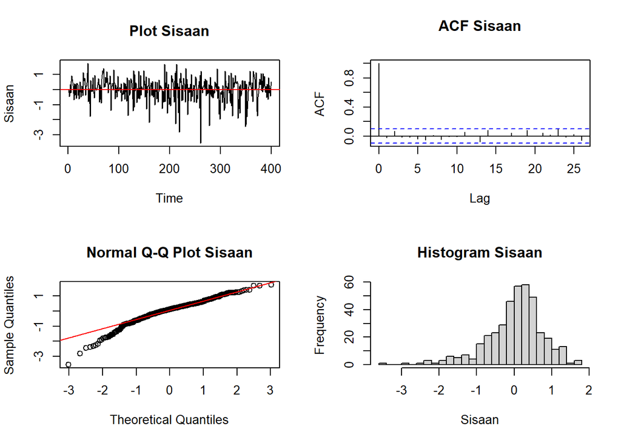

```r
sisaan <- as.numeric(residuals(fit_best))

par(mfrow = c(2, 2))
ts.plot(sisaan, main = "Plot Sisaan", ylab = "Sisaan")
abline(h = 0, col = "red")
acf(sisaan, main = "ACF Sisaan")
qqnorm(sisaan, main = "Normal Q-Q Plot Sisaan"); qqline(sisaan, col = "red")
hist(sisaan, breaks = 20, main = "Histogram Sisaan", xlab = "Sisaan")
```

```r
par(mfrow = c(1, 1))
```

## Uji Autokorelasi Sisaan (Ljung-Box)

$H_0$ : Tidak ada autokorelasi pada sisaan

$H_1$ : Terdapat autokorelasi pada sisaan

```r
uji_lb <- Box.test(sisaan, lag = 20, type = "Ljung-Box",
                   fitdf = best_order[1] + best_order[3])
uji_lb
```

```
##
##  Box-Ljung test
##
## data:  sisaan
## X-squared = 14.478, df = 17, p-value = 0.633
```

## Uji Kenormalan Sisaan

$H_0$ : Sisaan menyebar normal

$H_1$ : Sisaan tidak menyebar normal

```r
uji_sw <- shapiro.test(sisaan)
uji_jb <- tseries::jarque.bera.test(sisaan)
uji_sw
```

```
##
##  Shapiro-Wilk normality test
##
## data:  sisaan
## W = 0.94926, p-value = 1.758e-10
```

```r
uji_jb
```

```
##
##  Jarque Bera Test
##
## data:  sisaan
## X-squared = 143.48, df = 2, p-value < 2.2e-16
```

## Uji Nilai Tengah Sisaan

$H_0$ : Nilai tengah sisaan sama dengan nol

$H_1$ : Nilai tengah sisaan tidak sama dengan nol

```r
uji_t <- t.test(sisaan, mu = 0, alternative = "two.sided")
uji_t
```

```
##
##  One Sample t-test
##
## data:  sisaan
## t = 0.52501, df = 399, p-value = 0.5999
## alternative hypothesis: true mean is not equal to 0
## 95 percent confidence interval:
##  -0.05383477  0.09306515
## sample estimates:
##  mean of x
## 0.01961519
```

## Uji Kehomogenan Ragam Sisaan

Kehomogenan ragam diperiksa dengan uji Ljung-Box pada kuadrat sisaan (uji McLeod-Li), untuk mendeteksi adanya efek ARCH.

$H_0$ : Ragam sisaan homogen (tidak ada efek ARCH)

$H_1$ : Ragam sisaan tidak homogen

```r
uji_arch <- Box.test(sisaan^2, lag = 20, type = "Ljung-Box")
uji_arch
```

```
##
##  Box-Ljung test
##
## data:  sisaan^2
## X-squared = 20.691, df = 20, p-value = 0.4155
```

# Overfitting

Model terbaik diuji dengan menambah satu orde pada komponen AR dan MA. Model dengan tambahan parameter dianggap tidak lebih baik apabila parameter tambahannya tidak signifikan dan AIC-nya tidak lebih kecil.

```r
p <- best_order[1]; d <- best_order[2]; q <- best_order[3]

fit_over1 <- Arima(train, order = c(p + 1, d, q))
fit_over2 <- Arima(train, order = c(p, d, q + 1))

cat("ARIMA(", p + 1, ",", d, ",", q, ")\n", sep = "")
```

```
## ARIMA(2,1,2)
```

```r
lmtest::coeftest(fit_over1)
```

```
##
## z test of coefficients:
##
##      Estimate Std. Error z value Pr(>|z|)
## ar1  0.247754   0.283579  0.8737 0.382298
## ar2  0.166862   0.089494  1.8645 0.062249 .
## ma1 -0.915817   0.285956 -3.2027 0.001362 **
## ma2  0.005192   0.251827  0.0206 0.983551
## ---
## Signif. codes:  0 '***' 0.001 '**' 0.01 '*' 0.05 '.' 0.1 ' ' 1
```

```r
cat("\nARIMA(", p, ",", d, ",", q + 1, ")\n", sep = "")
```

```
##
## ARIMA(1,1,3)
```

```r
lmtest::coeftest(fit_over2)
```

```
##
## z test of coefficients:
##
##      Estimate Std. Error z value  Pr(>|z|)
## ar1  0.458944   0.191702  2.3941   0.01666 *
## ma1 -1.128884   0.193116 -5.8456 5.047e-09 ***
## ma2  0.319641   0.142458  2.2438   0.02485 *
## ma3 -0.107944   0.058643 -1.8407   0.06567 .
## ---
## Signif. codes:  0 '***' 0.001 '**' 0.01 '*' 0.05 '.' 0.1 ' ' 1
```

```r
data.frame(
  Model = c(nama_best,
            paste0("ARIMA(", p + 1, ",", d, ",", q, ")"),
            paste0("ARIMA(", p, ",", d, ",", q + 1, ")")),
  AIC = c(fit_best$aic, fit_over1$aic, fit_over2$aic)
) |> knitr::kable(digits = 3)
```

| Model | AIC |
| --- | --- |
| ARIMA(1,1,2) | 909.060 |
| ARIMA(2,1,2) | 908.387 |
| ARIMA(1,1,3) | 908.075 |

# Peramalan

## Ramalan pada Data Uji

Ramalan dilakukan sebanyak 100 periode ke depan (observasi 401 - 500) dan dibandingkan dengan data uji.

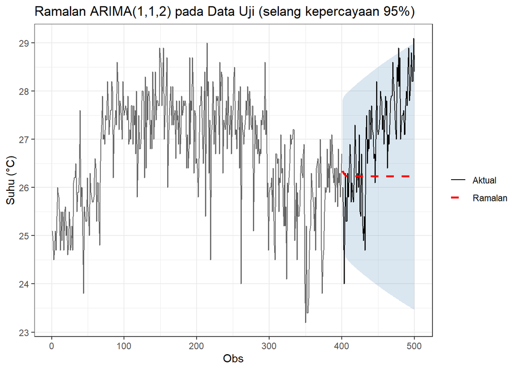

```r
fc <- forecast(fit_best, h = length(test))

df_train <- data.frame(Obs = 1:n_train, Nilai = as.numeric(train))
df_fc <- data.frame(
  Obs     = (n_train + 1):500,
  Aktual  = test,
  Ramalan = as.numeric(fc$mean),
  Lower95 = as.numeric(fc$lower[, 2]),
  Upper95 = as.numeric(fc$upper[, 2])
)

ggplot() +
  geom_line(data = df_train, aes(x = Obs, y = Nilai), color = "grey40") +
  geom_ribbon(data = df_fc, aes(x = Obs, ymin = Lower95, ymax = Upper95),
              fill = "steelblue", alpha = 0.2) +
  geom_line(data = df_fc, aes(x = Obs, y = Aktual, color = "Aktual")) +
  geom_line(data = df_fc, aes(x = Obs, y = Ramalan, color = "Ramalan"),
            linetype = "dashed", linewidth = 1) +
  scale_color_manual(values = c(Aktual = "black", Ramalan = "red")) +
  theme_bw() + labs(x = "Obs", y = "Suhu (°C)", color = "") +
  ggtitle(paste("Ramalan", nama_best, "pada Data Uji (selang kepercayaan 95%)"))
```

## Ukuran Akurasi

Dua skema evaluasi digunakan:

1. 100 periode diramalkan sekaligus dari akhir data latih.
2. Parameter dari data latih dipakai, tetapi setiap ramalan memanfaatkan data aktual periode sebelumnya.

```r
metrik <- function(aktual, ramalan) {
  c(RMSE = sqrt(mean((aktual - ramalan)^2)),
    MAE  = mean(abs(aktual - ramalan)),
    MAPE = mean(abs((aktual - ramalan) / aktual)) * 100)
}

# Ramalan satu langkah dengan parameter dari data latih
fit_all  <- Arima(y, model = fit_best)
satu_lgk <- as.numeric(fitted(fit_all))[(n_train + 1):500]

hasil <- rbind(
  `Multi-langkah (100 periode)` = metrik(test, as.numeric(fc$mean)),
  `Satu langkah ke depan`       = metrik(test, satu_lgk)
)
knitr::kable(hasil, digits = 4)
```

|  | RMSE | MAE | MAPE |
| --- | --- | --- | --- |
| Multi-langkah (100 periode) | 1.3304 | 1.1366 | 4.1408 |
| Satu langkah ke depan | 0.6385 | 0.4964 | 1.8412 |

Nilai MAPE ramalan multi-langkah adalah 4.14% dan ramalan satu langkah adalah 1.84%.

Model ARIMA(p,1,q) tanpa konstanta menghasilkan ramalan jangka panjang yang cenderung **mendatar** (mendekati nilai terakhir data latih), sehingga akurasi ramalan multi-langkah biasanya lebih rendah dibanding ramalan satu langkah. Selain itu, data suhu harian memiliki **pola musiman tahunan** (rata-rata bulanan pada 500 data awal berkisar dari sekitar 25,4 °C pada Desember hingga sekitar 27,8 °C pada Mei), sedangkan 500 observasi belum mencakup dua siklus tahunan penuh. Pola ini tidak dapat ditangkap oleh model ARIMA non-musiman.

# Kesimpulan

1. Data latih (observasi 1 - 400) tidak stasioner dalam rataan (ACF menurun perlahan dan uji ADF p-value = 0.111), sehingga dilakukan differencing pertama ($d = 1$) dan data menjadi stasioner (uji ADF p-value = 0.01).
2. Berdasarkan plot ACF dan PACF data hasil differencing, model dugaan utama adalah ARIMA(0,1,1), dibandingkan dengan beberapa model alternatif.
3. Model terbaik berdasarkan signifikansi parameter dan AIC adalah **ARIMA(1,1,2)**.
4. Hasil diagnostik sisaan (autokorelasi, kenormalan, nilai tengah, dan kehomogenan ragam) disajikan pada bagian Diagnostik Sisaan. Bagian yang asumsinya tidak terpenuhi perlu dicatat sebagai keterbatasan model.
5. Ramalan pada data uji menghasilkan MAPE 4.14% (multi-langkah) dan 1.84% (satu langkah).
6. Untuk pengembangan lebih lanjut, dapat dicoba model musiman (SARIMA) atau penambahan data agar pola musiman tahunan dapat ditangkap.